# CNN

# CNN(Convolution Neural Network)

## 0. Introduction

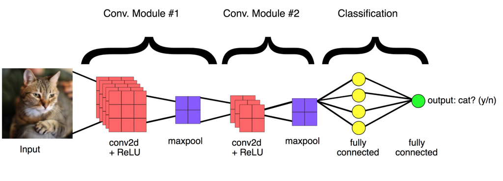

CNN8.jpg

convolution neural network는 말 그대로 **convolution** 연산이 들어가는 뉴럴 네트워크를 의미한다. CNN은 고양이가 이미지를 볼 때 바라보는 위치에 따라서 자극받는 뇌의 부분이 다르다는 점을 착안해 만들어졌다고 한다. CNN은 convolution연산 외에도 중간중간 RELU와 max-pooling을 적용하며, 마지막에는 필수적으로 FC(Fully Connected Layer)을 통과하여 labeling을 하게 된다.

convolution, max-pooling, FC가 무엇인지 하나하나 알아보자

## 1. Convolution?

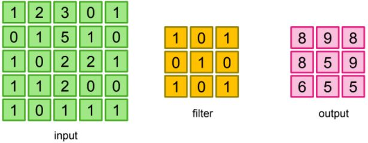

CNN1.jpg

Convolution은 이미지 위에서 stride만큼 filter를 이동시키면서 겹쳐지는 부분의 각 원소의 값을 곱해서 더한 값을 출력으로 하는 연산이다. 이 과정을 통해서 이미지의 특성을 추출해내는 것이다

위 그림에서 첫번째 연산은 $ 1*1 + 2*0 + 3*1 + 0*0 + 1*1 + 5*0 + 1*1 + 0*0 + 2*1 = 8 $ 이다. convolution은 이 과정을 필터를 이동시키면서 진행해 최종적인 output을 도출한다.

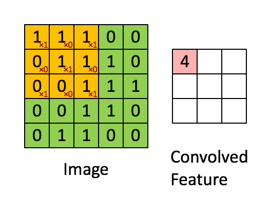

CNN

### 1-1 이미지

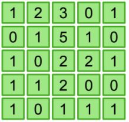

CNN2.jpg

input data인 이미지는 다음과 같은 요소로 구성된다: **batch_size, channel, height, width**

채널의 수는 흑백인지 컬러인지에 따라서 달라지는데 흑백 이미지의 경우 채널 1개로 구성되며, 컬러 이미지는 R G B 빨강 초록 파랑 3개의 채널로 구성된다. 위의 초록 그림이 3장 겹쳐있다고 생각하면 된다. 그렇다면 Input data에 적힌 각각의 숫자는 무엇을 의미할까? 이는 이미지를 구성하는 최소단위인 픽셀의 값으로, 이미지를 이루는 점이라고 생각하면 된다. 픽셀은 이미지의 밝기와 컬러를 나타내며 픽셀들이 모여 하나의 이미지를 만들어낸다. height와 width의 곱은 이미지가 총 몇개의 픽셀로 구성되어 있는지 나타내준다

### 1-2 필터

필터는 다음과 같은 요소로 구성된다: **in_channels, out_channels, kernel_size, stride, padding**

#### 1) in_channels, out_channels, kernel_size

Input data가 3x28x28로 3개의 채널로 구성되어있다고 하자. 이에 따라 필터 또한 3개의 channel로 구성되어야 하며, in_channels의 값은 3이다. kernel_size는 필터의 가로/세로 길이를 나타내는데, 필터가 3x5x5 사이즈로 구성되어 있으면 kernel_size는 5다

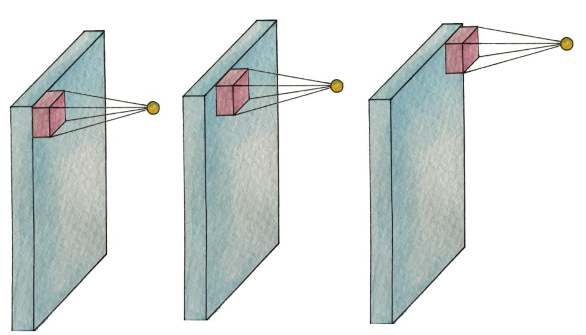

구체적인 연산과정은 아래와 같다. 이미지의 각 채널과 filter의 연산과정으로 3개의 결과물이 출력되며 이 결과물들의 각 원소별 덧셈 과정을 통해 최종적인 결과물이 산출된다. 즉 채널의 수와 상관없이 하나의 feature map이 만들어진다는 것이다

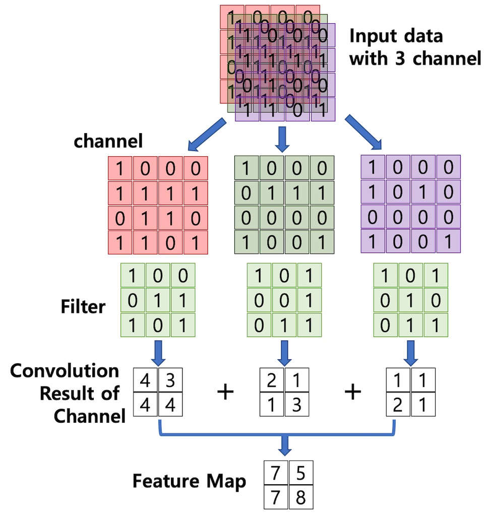

out_channel은 몇 종류의 필터를 사용되는지에 따라 결정된다. 채널의 수와 상관없이 하나의 필터를 사용할 때 하나의 feature map이 만들어지며, 4종류의 필터를 사용한다면 총 4개의 feature map이 만들어질 것이다. 이 때 out_channel 값이 4다

지금까지의 말을 정리하면, input size: 3x28x28 , filter size: 3x5x5, 4종류의 필터 사용 : **in_channel=3, out_channel=4 kernel_size=5**

#### 2) stride

stride는 필터를 이동시킬 때 몇칸 씩 이동하는지를 나타내는 숫자다. 아래는 필터가 한칸씩 이동하고 있기 때문에 Sride는 1이다

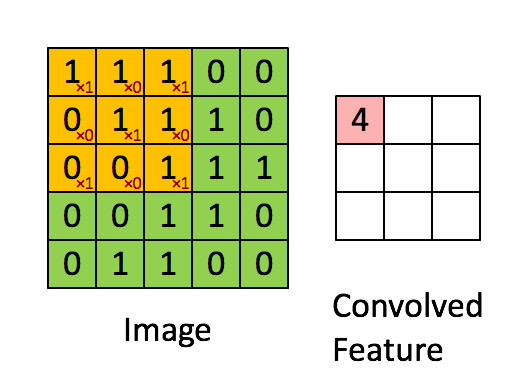

SegmentLocal

#### 3) padding

padding은 input data인 이미지 외각에 특정 값으로 채워주는 것을 의미하며, 일반적으로 0으로 채워주기 때문에 zero-padding이라 한다. padding은 convolution 연산 이후에 정보가 손실되는 것을 막기 위해 사용하는 것인데, 자세히 알아보자.

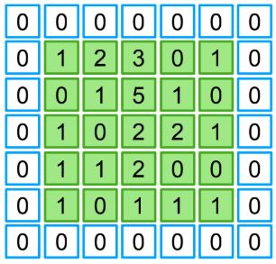

CNN7.jpg

convolution 연산 이후에 나오는 output size를 구하는 공식은 다음과 같다: $((inputsize) - (filtersize)) / (Stride) + 1 $

input_size가 7 filter_size가 3일 때 공식에 대입을 하면,

Stride가 1일 때 $(7 - 3) / 1 +1 = 5$, 5x5사이즈

Stride가 2일 때 $(7 - 3) / 2 +1 = 3$, 3x3사이즈가 output size다

결과를 살펴보면 7x7사이즈였던 이미지가 연산을 진행함에 따라 사이즈가 줄어드는 것을 확인할 수 있고, 이는 기존의 정보를 잃어버리는 결과를 가져온다.

이를 방지하기 위해 사용하는 것이 zero padding이다. 기존 이미지에 zero padding을 하게되면 7x7사이즈가 9x9가 된다. 이에 stride 1 filter_size=3으로 연산을 진행하면 $(9 - 3) / 1 +1 = 7$로 이미지 사이즈가 보존되는 것을 확인할 수 있다.

일반적으로 output size를 구하기 위해 다음 공식을 사용한다. $((inputsize) + (padding*2) - (filtersize)) / (Stride) + 1 $

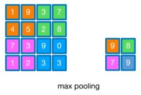

CNN9.jpg

max-pooling 작업은 일반적으로 convolution 연산 이후에 진행이 되는데, size가 2라고 하면 각각의 2x2 사이즈에서 가장 큰 값을 출력하는 과정이다. 이는 가장 큰 값이 이미지의 특징을 대표한다는 점을 기반으로 하고 있다. Max pooling은 왜 하는 걸까? convolution 연산 output을 그대로 사용하게 되면 수많은 feature가 만들어지고 이는 오버피팅의 문제를 가져온다. Max-pooling은 기존의 이미지 사이즈를 반으로 줄여(Size 2 기준) 오버피팅을 방지해주며 더 나아가 연산 과정을 줄여준다

참고자료 : https://hunkim.github.io/ml/

https://deeplearningzerotoall.github.io/season2/

https://twlab.tistory.com/23

https://machine-geon.tistory.com/46

https://towardsdatascience.com/introduction-to-convolutional-neural-network-cnn-de73f69c5b83